# Particles In A Potential

## Introduction

The following potential is given:

$$\begin{equation}
V_{ij} = \dfrac{q_i q_j}{|\mathbf{r}_i - \mathbf{r}_j|} \,+\, \dfrac{1}{|\mathbf{r}_i - \mathbf{r}_j|^8} \; , \quad q=\pm 1, \; \mathbf{r}_i \in \mathbb{R}^3
\end{equation}$$

The system of $N$ particles is embedded in a heat bath of temperature $T$. The partition sum is given by:

$$\begin{equation}
Z = \int \prod^N_{i=1} d\mathbf{r}_i \exp \left[-\frac1T \sum_{i < j} V(\mathbf{r}_i, \mathbf{r}_j)\right]
\end{equation}$$

The first task is to study the phase transitions of this system. We expect to find transitions from some kind of ionic crystal to a liquid to a molecular gas and to a single particle gas state.

## The Potential V

The potential comprises a coulomb force and a hard shell force. For same charge sign particles the interaction is always repulsive. For opposite charges the interaction is attractive for large distances. The behavior of the system is invariant to the proportion and scaling of both contributions, since all function are equivalent up to a global scaling factor and the choice of a distance unit.

In the following the shape of the potential is shown for the attractive and repulsive case.

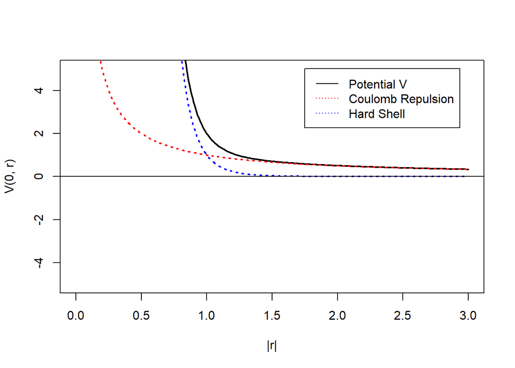

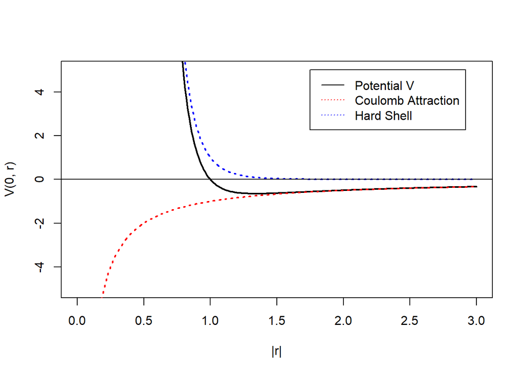

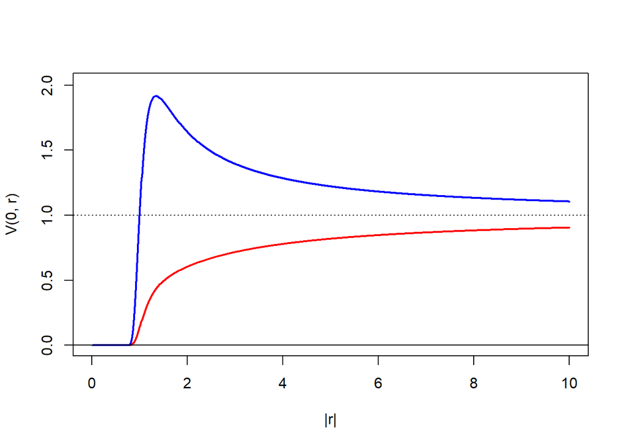

The attractive and repulsive regions can be seen more clearly in the derivative of the potential, which is proportional to the force vector acting on the particles. A positive value represents attraction and a negative repulsion.

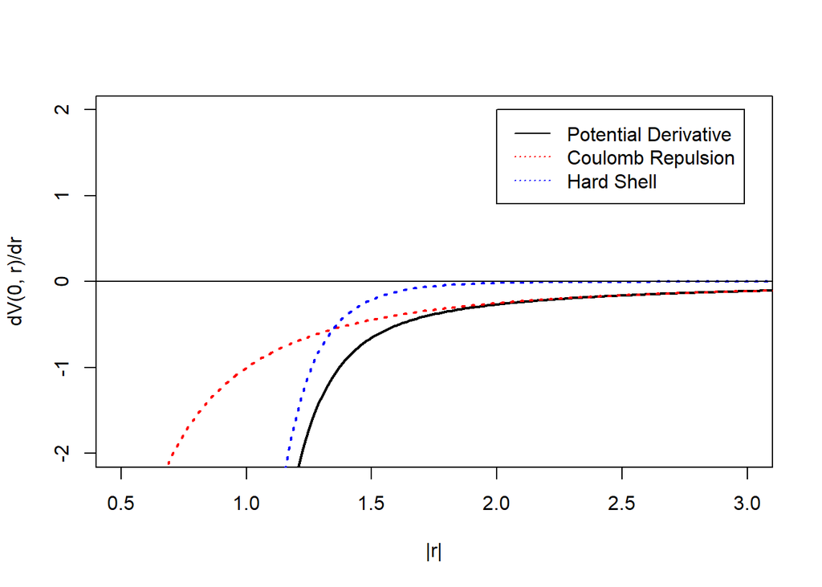

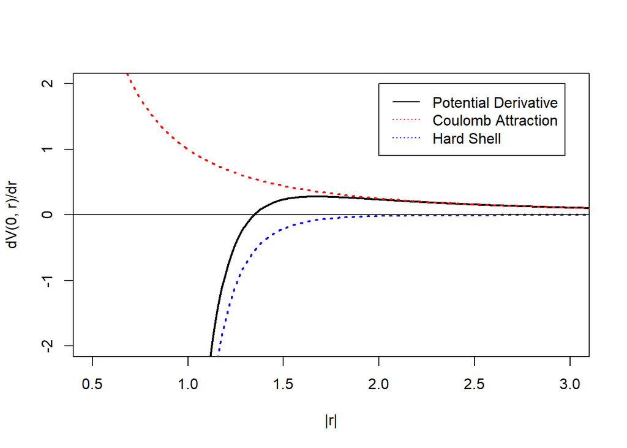

## The Partition Sum

$$\begin{equation}
Z = \int \prod^N_{i=1} d\mathbf{r}_i \exp \left[-\frac1T \sum_{i < j} \dfrac{q_i q_j}{|\mathbf{r}_i - \mathbf{r}_j|} \,+\, \dfrac{1}{|\mathbf{r}_i - \mathbf{r}_j|^8} \right]
\end{equation}$$

$$\begin{equation}
Z^{N=3} = \int d\mathbf{r}_1 d\mathbf{r}_2 d\mathbf{r}_3 \exp \left[-\frac1T \left( \dfrac{q_1 q_2}{|\mathbf{r}_1 - \mathbf{r}_2|} \,+\, \dfrac{q_1 q_3}{|\mathbf{r}_1 - \mathbf{r}_3|} \,+\, \dfrac{q_2 q_3}{|\mathbf{r}_2 - \mathbf{r}_3|} \,+\, \dfrac{1}{|\mathbf{r}_1 - \mathbf{r}_2|^8} \,+\, \dfrac{1}{|\mathbf{r}_1 - \mathbf{r}_3|^8} \,+\, \dfrac{1}{|\mathbf{r}_2 - \mathbf{r}_3|^8} \right) \right]
\end{equation}$$

The partition sum depends primarily on the temperature $T$, but also on the number of particles $N$ in the system.